[Report](https://aishwaryasingh51.github.io/Predict-Podcast-Listening-Time/)

# Predict Podcast Listening Time 🎙️

## *Aishwarya Singh*

##### Professional Certificate in Data Analytics Imperial College Business School

## Dataset Description 📋

The dataset for this competition (both train and test) was generated from a deep learning model trained on the Podcast Listening Time Prediction dataset. Feature distributions are close to, but not exactly the same, as the original. Feel free to use the original dataset as part of this competition, both to explore differences as well as to see whether incorporating the original in training improves model performance.

### Data Files 📁

**train.csv** - the training dataset; `Listening_Time_minutes` is the target.  
**test.csv** - the test dataset; your objective is to predict the `Listening_Time_minutes` for each row.  
**sample_submission.csv** - a sample submission file in the correct format.

## Submission Criteria ✅

Submissions are scored on the Root Mean Squared Error.  
RMSE is defined as:

$$ \textrm{RMSE} = \left( \frac{1}{N} \sum_{i=1}^{N} (y_i - \widehat{y}_i)^2 \right)^{\frac{1}{2}} $$

where $y_i$ is the true value for instance $i$, and $\widehat{y}_i$ is the predicted value

### Submission File

For each `id` in the test set, you must predict the `Listening_Time_minutes` of the podcast. The file should contain a header and have the following format:

```
id,Listening_Time_minutes
750000,45.437
750001,45.437
750002,45.437
```

## Import Basic Libraries ⬇️

```python
import pandas as pd
import numpy as np
import matplotlib.pyplot as plt
import seaborn as sns
```

## Importing and Dataset Overview 🔎

```python
# Load Data
podcast_train = pd.read_csv("podcast_train.csv")
podcast_test = pd.read_csv("podcast_test.csv")
podcast_submission = pd.read_csv("podcast_sample_submission.csv")

# Preview the training data
print("Training Data Preview:")
display(podcast_train.head())

# Preview the test data
print("Test Data Preview:")
display(podcast_test.head())

# Preview the submission data
print("Sample Submission Data Preview:")
display(podcast_submission.head())
```

```
Training Data Preview:
```

|  | id | Podcast_Name | Episode_Title | Episode_Length_minutes | Genre | Host_Popularity_percentage | Publication_Day | Publication_Time | Guest_Popularity_percentage | Number_of_Ads | Episode_Sentiment | Listening_Time_minutes |
| --- | --- | --- | --- | --- | --- | --- | --- | --- | --- | --- | --- | --- |
| 0 | 0 | Mystery Matters | Episode 98 | NaN | True Crime | 74.81 | Thursday | Night | NaN | 0.0 | Positive | 31.41998 |
| 1 | 1 | Joke Junction | Episode 26 | 119.80 | Comedy | 66.95 | Saturday | Afternoon | 75.95 | 2.0 | Negative | 88.01241 |
| 2 | 2 | Study Sessions | Episode 16 | 73.90 | Education | 69.97 | Tuesday | Evening | 8.97 | 0.0 | Negative | 44.92531 |
| 3 | 3 | Digital Digest | Episode 45 | 67.17 | Technology | 57.22 | Monday | Morning | 78.70 | 2.0 | Positive | 46.27824 |
| 4 | 4 | Mind & Body | Episode 86 | 110.51 | Health | 80.07 | Monday | Afternoon | 58.68 | 3.0 | Neutral | 75.61031 |

```
Test Data Preview:
```

|  | id | Podcast_Name | Episode_Title | Episode_Length_minutes | Genre | Host_Popularity_percentage | Publication_Day | Publication_Time | Guest_Popularity_percentage | Number_of_Ads | Episode_Sentiment |
| --- | --- | --- | --- | --- | --- | --- | --- | --- | --- | --- | --- |
| 0 | 750000 | Educational Nuggets | Episode 73 | 78.96 | Education | 38.11 | Saturday | Evening | 53.33 | 1.0 | Neutral |
| 1 | 750001 | Sound Waves | Episode 23 | 27.87 | Music | 71.29 | Sunday | Morning | NaN | 0.0 | Neutral |
| 2 | 750002 | Joke Junction | Episode 11 | 69.10 | Comedy | 67.89 | Friday | Evening | 97.51 | 0.0 | Positive |
| 3 | 750003 | Comedy Corner | Episode 73 | 115.39 | Comedy | 23.40 | Sunday | Morning | 51.75 | 2.0 | Positive |
| 4 | 750004 | Life Lessons | Episode 50 | 72.32 | Lifestyle | 58.10 | Wednesday | Morning | 11.30 | 2.0 | Neutral |

```
Sample Submission Data Preview:
```

|  | id | Listening_Time_minutes |
| --- | --- | --- |
| 0 | 750000 | 45.437 |
| 1 | 750001 | 45.437 |
| 2 | 750002 | 45.437 |
| 3 | 750003 | 45.437 |
| 4 | 750004 | 45.437 |

```python
# Data Overview
print("Training Data Info:\n")
display(podcast_train.info())

# Stat summary
print("Training Data Statistical Summary:")
display(podcast_train.describe().round(2))

# Missing value summary sorted by most missing
missing_values = podcast_train.isnull().sum().sort_values(ascending=False)
missing_percent = ((missing_values / len(podcast_train)) * 100).round(2)
missing_df = pd.DataFrame({'Missing Values': missing_values, 'Percent': missing_percent})
print("Training Data Missing Values Summary:")
display(missing_df[missing_df['Missing Values'] > 0])

# Display categorical cardinalities
cat_cols = podcast_train.select_dtypes(include=['object', 'category']).columns.tolist()
cardinality = podcast_train[cat_cols].nunique().sort_values(ascending=False)
print("Training Data Categorical Cardinalities:")
display(cardinality.to_frame('nunique'))
```

```
Training Data Info:

<class 'pandas.core.frame.DataFrame'>
RangeIndex: 750000 entries, 0 to 749999
Data columns (total 12 columns):
 #   Column                       Non-Null Count   Dtype
---  ------                       --------------   -----
 0   id                           750000 non-null  int64
 1   Podcast_Name                 750000 non-null  object
 2   Episode_Title                750000 non-null  object
 3   Episode_Length_minutes       662907 non-null  float64
 4   Genre                        750000 non-null  object
 5   Host_Popularity_percentage   750000 non-null  float64
 6   Publication_Day              750000 non-null  object
 7   Publication_Time             750000 non-null  object
 8   Guest_Popularity_percentage  603970 non-null  float64
 9   Number_of_Ads                749999 non-null  float64
 10  Episode_Sentiment            750000 non-null  object
 11  Listening_Time_minutes       750000 non-null  float64
dtypes: float64(5), int64(1), object(6)
memory usage: 68.7+ MB
```

```
None
```

```
Training Data Statistical Summary:
```

|  | id | Episode_Length_minutes | Host_Popularity_percentage | Guest_Popularity_percentage | Number_of_Ads | Listening_Time_minutes |
| --- | --- | --- | --- | --- | --- | --- |
| count | 750000.00 | 662907.00 | 750000.00 | 603970.00 | 749999.00 | 750000.00 |
| mean | 374999.50 | 64.50 | 59.86 | 52.24 | 1.35 | 45.44 |
| std | 216506.50 | 32.97 | 22.87 | 28.45 | 1.15 | 27.14 |
| min | 0.00 | 0.00 | 1.30 | 0.00 | 0.00 | 0.00 |
| 25% | 187499.75 | 35.73 | 39.41 | 28.38 | 0.00 | 23.18 |
| 50% | 374999.50 | 63.84 | 60.05 | 53.58 | 1.00 | 43.38 |
| 75% | 562499.25 | 94.07 | 79.53 | 76.60 | 2.00 | 64.81 |
| max | 749999.00 | 325.24 | 119.46 | 119.91 | 103.91 | 119.97 |

```
Training Data Missing Values Summary:
```

|  | Missing Values | Percent |
| --- | --- | --- |
| Guest_Popularity_percentage | 146030 | 19.47 |
| Episode_Length_minutes | 87093 | 11.61 |
| Number_of_Ads | 1 | 0.00 |

```
Training Data Categorical Cardinalities:
```

|  | nunique |
| --- | --- |
| Episode_Title | 100 |
| Podcast_Name | 48 |
| Genre | 10 |
| Publication_Day | 7 |
| Publication_Time | 4 |
| Episode_Sentiment | 3 |

## Exploratory Data Analysis 📊

```python
# Set Up Target, Numeric and Categorical Columns
target_col = 'Listening_Time_minutes'

num_cols = (
    podcast_train.select_dtypes(include=[np.number])
    .columns.drop(['id'], errors='ignore')
    .tolist()
)
cat_cols = (
    podcast_train.select_dtypes(include=['object', 'category'])
    .columns.drop(['id'], errors='ignore')
    .tolist()
)

# Ensure target exists and is numeric
assert target_col in podcast_train.columns, f"Missing {target_col} in train."
```

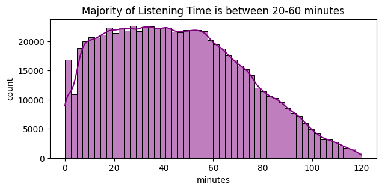

```python
# Listening Time distribution
plt.figure(figsize=(7,3))
sns.histplot(podcast_train[target_col], bins=50, kde=True, color='purple')
plt.title('Majority of Listening Time is between 20-60 minutes')
plt.xlabel('minutes'); plt.ylabel('count')
plt.show()
```

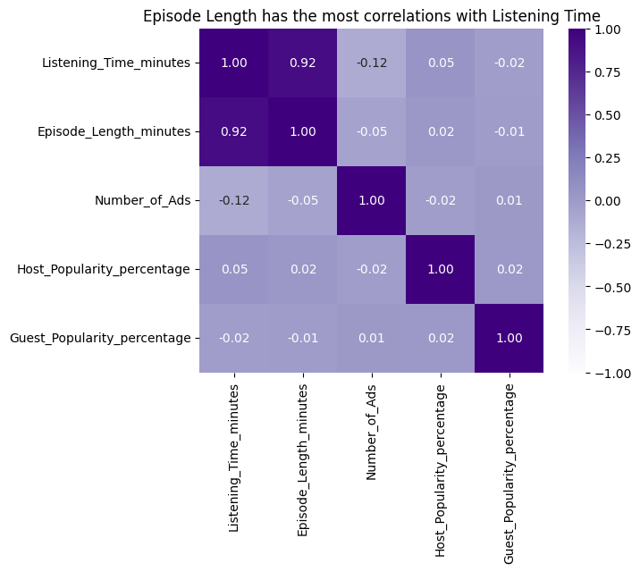

```python
# Top numeric correlations with Listening Time
num_for_corr = [c for c in num_cols if c != target_col]

corr_to_target = (
    podcast_train[num_for_corr + [target_col]].corr()[target_col]
    .drop(labels=[target_col])
    .sort_values(key=np.abs, ascending=False)
)

top_feats = corr_to_target.head(8).index.tolist()
top_num = top_feats[:4]

# Correlation matrix for target + top features
corr_mat = podcast_train[[target_col] + top_feats].corr()

# Heatmap
plt.figure(figsize=(7,5))
sns.heatmap(corr_mat, annot=True, fmt=".2f", cmap="Purples", square=True, vmin=-1, vmax=1)
plt.title(f"Episode Length has the most correlations with Listening Time")
plt.show()
```

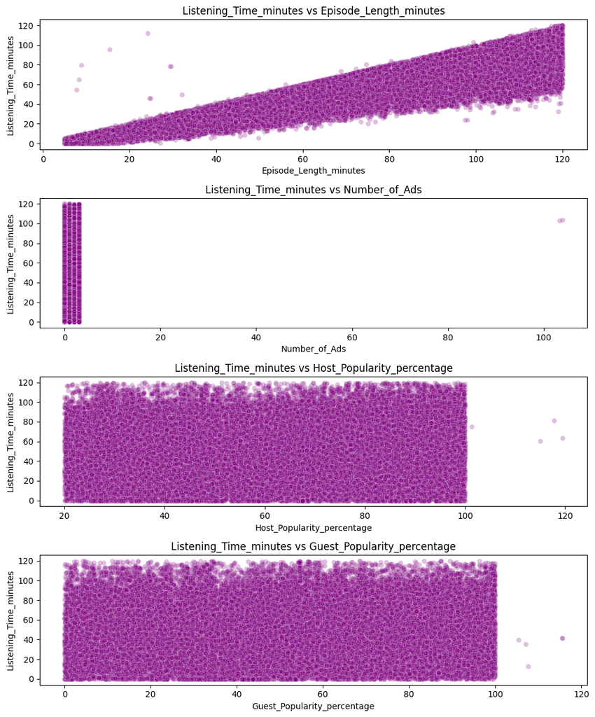

```python
# Scatter plots: top numeric features vs Listening Time
sample = podcast_train.sample(min(100_000, len(podcast_train)), random_state=51)
n = len(top_num)
plt.figure(figsize=(10, 3*n))

for i, col in enumerate(top_num, 1):
    plt.subplot(n, 1, i)
    sns.scatterplot(data=sample, x=col, y=target_col, alpha=0.25, color='purple')
    plt.title(f'{target_col} vs {col}')
    plt.xlabel(col); plt.ylabel(target_col)
plt.tight_layout(); plt.show()
```

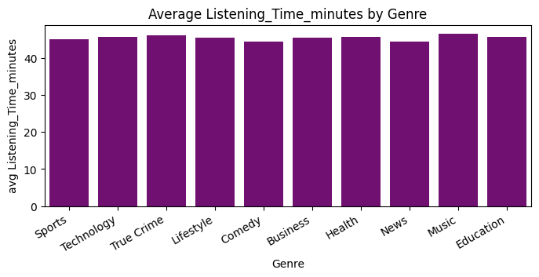

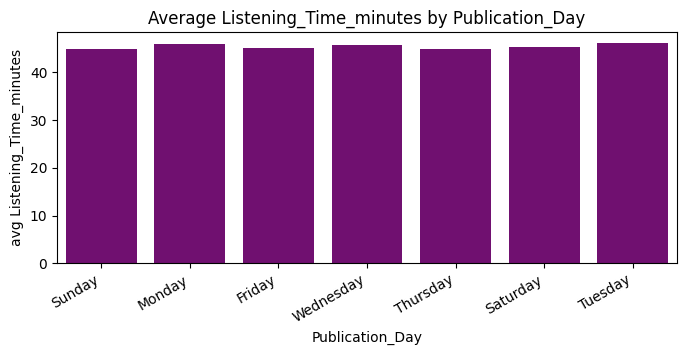

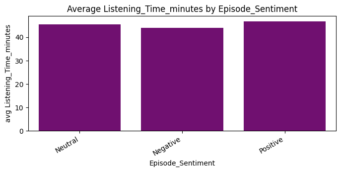

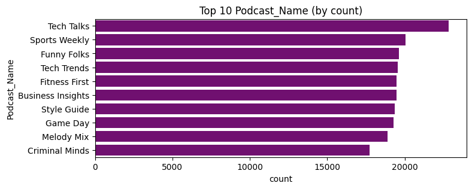

```python
# Categorical Cardinality and Target-by-Category Bar Charts
if cat_cols:

    # Choose low-cardinality columns for bar charts (<= 20 unique values)
    low_card = [c for c in cat_cols if podcast_train[c].nunique() <= 20]
    # Prefer common interpretable columns if present
    preferred = [c for c in ['Genre','Publication_Day','Episode_Sentiment'] if c in low_card]
    plot_cols = preferred[:3] if preferred else low_card[:3]

    for col in plot_cols:
        order = podcast_train[col].value_counts().index
        agg = podcast_train.groupby(col, as_index=False)[target_col].mean()
        plt.figure(figsize=(8,3))
        sns.barplot(data=agg, x=col, y=target_col, order=order, color='purple')
        plt.title(f'Average {target_col} by {col}')
        plt.xlabel(col); plt.ylabel(f'avg {target_col}')
        plt.xticks(rotation=30, ha='right')
        plt.show()

    # For high-card columns show top counts only
    high_card = [c for c in cat_cols if podcast_train[c].nunique() > 20]
    for col in high_card[:1]:  # one chart
        top_counts = podcast_train[col].value_counts().head(10)
        plt.figure(figsize=(8,3))
        sns.barplot(x=top_counts.values, y=top_counts.index, color='purple')
        plt.title(f'Top 10 {col} (by count)')
        plt.xlabel('count'); plt.ylabel(col)
        plt.show()
```

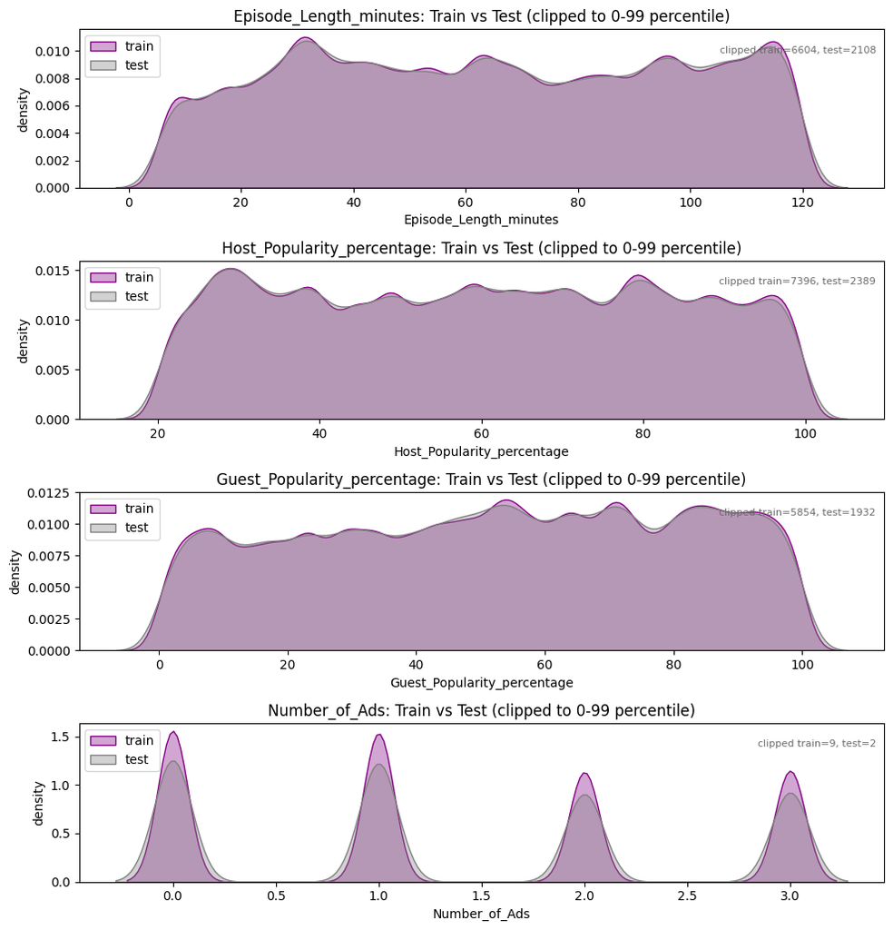

```python
# Train vs Test: numeric distribution check (robust to outliers; plotting only)
num_compare = [c for c in ['Episode_Length_minutes','Host_Popularity_percentage',
                           'Guest_Popularity_percentage','Number_of_Ads'] if c in num_cols]
n = len(num_compare)

if n > 0:
    q_low, q_high = 0.005, 0.995  # clip to 0.5%–99.5% for visualization
    plt.figure(figsize=(10, 2.6*n))
    for i, col in enumerate(num_compare, 1):
        plt.subplot(n, 1, i)

        lo = podcast_train[col].quantile(q_low)
        hi = podcast_train[col].quantile(q_high)

        # Clip both train and test to the same bounds so shapes are comparable
        tr = podcast_train[col].clip(lo, hi)
        te = podcast_test[col].clip(lo, hi)

        sns.kdeplot(tr, label='train', fill=True, alpha=0.35, color='purple')
        sns.kdeplot(te, label='test',  fill=True, alpha=0.35, color='gray')

        # Small note on how many values were outside (for context)
        tr_out = int(((podcast_train[col] < lo) | (podcast_train[col] > hi)).sum())
        te_out = int(((podcast_test[col]  < lo) | (podcast_test[col]  > hi)).sum())
        plt.title(f'{col}: Train vs Test (clipped to {int(q_low*100)}-{int(q_high*100)} percentile)')
        plt.xlabel(col); plt.ylabel('density'); plt.legend()
        plt.text(0.99, 0.85, f'clipped train={tr_out}, test={te_out}', transform=plt.gca().transAxes,
                 ha='right', fontsize=8, color='dimgray')

    plt.tight_layout(); plt.show()
```

## Data Cleaning and Preperation 🧹

### Cleaning Numerical and Categorical Columns

```python
# Make a copy and Drop the 'id' column
test_ids = podcast_test['id'].copy() if 'id' in podcast_test.columns else None
podcast_train.drop(columns=['id'], inplace=True, errors='ignore')
podcast_test.drop(columns=['id'], inplace=True, errors='ignore')

# Find columns present in both train and test
common_cols = podcast_train.columns.intersection(podcast_test.columns)

# Split columns by type
# Numerical
numerical_cols = podcast_train[common_cols].select_dtypes(include=[np.number]).columns

# Categorical
categorical_cols = podcast_train[common_cols].select_dtypes(include=['object', 'category']).columns

# Handle missing values in numerical columns
# For both train and test, fill missing values with the median calculated from the train set
train_medians = podcast_train[numerical_cols].median()
podcast_train[numerical_cols] = podcast_train[numerical_cols].fillna(train_medians)
podcast_test[numerical_cols] = podcast_test[numerical_cols].fillna(train_medians)

# Impute categorical values
if len(categorical_cols) > 0:
    train_modes = podcast_train[categorical_cols].mode(dropna=True)
    train_modes = train_modes.iloc[0] if not train_modes.empty else pd.Series(index=categorical_cols)
    for col in categorical_cols:
        mode_val = train_modes.get(col, None)
        if mode_val is not None:
            podcast_train[col] = podcast_train[col].fillna(mode_val)
            podcast_test[col] = podcast_test[col].fillna(mode_val)
```

### Final Checks before Modelling

```python
target_col = 'Listening_Time_minutes'
assert target_col not in common_cols, "Target must not be in feature columns."

print("Test numeric missing values:")
print(podcast_test[numerical_cols].isnull().sum())
print("\nTest categorical missing values:")
print(podcast_test[categorical_cols].isnull().sum())
print("\nFeature total missing values:\nTrain:",
      int(podcast_train[common_cols].isna().sum().sum()),
      "| Test:",
      int(podcast_test[common_cols].isna().sum().sum()))
```

```
Test numeric missing values:
Episode_Length_minutes         0
Host_Popularity_percentage     0
Guest_Popularity_percentage    0
Number_of_Ads                  0
dtype: int64

Test categorical missing values:
Podcast_Name         0
Episode_Title        0
Genre                0
Publication_Day      0
Publication_Time     0
Episode_Sentiment    0
dtype: int64

Feature total missing values:
Train: 0 | Test: 0
```

## Modelling the Data 🛠️

### Import Model Libraries ⬇️

```python
from sklearn.model_selection import train_test_split
from sklearn.ensemble import RandomForestRegressor
from sklearn.tree import DecisionTreeRegressor
from sklearn.ensemble import HistGradientBoostingRegressor
from sklearn.metrics import root_mean_squared_error
from sklearn.metrics import r2_score
```

### Define the Baseline RMSE

```python
# Define target variable
target_col = "Listening_Time_minutes"

X = podcast_train.drop(columns=[target_col])
y = podcast_train[target_col]

# 80/20 split
X_train, X_val, y_train, y_val = train_test_split(
    X, y, test_size=0.2, random_state=51
)

# Predict the training mean on validation
mean_value = y_train.mean()
y_pred = np.full(shape=len(y_val), fill_value=mean_value)

rmse_baseline = root_mean_squared_error(y_val, y_pred)
print(f"Baseline mean predictor RMSE: {rmse_baseline:.2f}")
```

```
Baseline mean predictor RMSE: 27.09
```

### Encode Categorical Values

```python
# Can be called on all the below models
cat_cols = X_train.select_dtypes(include=['object', 'category']).columns.tolist()
X_train_enc = pd.get_dummies(X_train, columns=cat_cols, drop_first=True)
X_val_enc = pd.get_dummies(X_val, columns=cat_cols, drop_first=True)
X_val_enc = X_val_enc.reindex(columns=X_train_enc.columns, fill_value=0)
```

### Decison Tree Regressor 🌲

```python
# max_depth and min_samples_leaf values to cycle through
depth_list = [6, 8, 10, 12, 14, None]
leaf_list = [5, 10, 20, 40]

best_rmse = None
best_params = None

# Looping through the above values to find the best RMSE
print("Decision Tree search:")
for d in depth_list:
    for leaf in leaf_list:
        model = DecisionTreeRegressor(
            random_state=51,
            max_depth=d,
            min_samples_leaf=leaf
        )
        model.fit(X_train_enc, y_train)
        preds = model.predict(X_val_enc)
        rmse = root_mean_squared_error(y_val, preds)
        print(f"max_depth={d} | min_samples_leaf={leaf} -> RMSE: {rmse:.2f}")
        if (best_rmse is None) or (rmse < best_rmse):
            best_rmse = rmse
            best_params = (d, leaf)

print("\nBest params:",
      f"max_depth={best_params[0]}, min_samples_leaf={best_params[1]} -> RMSE: {best_rmse:.2f}")

# Fit final DT on the best params
dt_model = DecisionTreeRegressor(
    random_state=51,
    max_depth=best_params[0],
    min_samples_leaf=best_params[1]
)
dt_model.fit(X_train_enc, y_train)
val_preds = dt_model.predict(X_val_enc)
rmse_dt = root_mean_squared_error(y_val, val_preds)
print(f"\nFinal Decision Tree RMSE: {rmse_dt:.2f}")
```

```
Decision Tree search:
max_depth=6 | min_samples_leaf=5 -> RMSE: 13.30
max_depth=6 | min_samples_leaf=10 -> RMSE: 13.30
max_depth=6 | min_samples_leaf=20 -> RMSE: 13.30
max_depth=6 | min_samples_leaf=40 -> RMSE: 13.30
max_depth=8 | min_samples_leaf=5 -> RMSE: 13.23
max_depth=8 | min_samples_leaf=10 -> RMSE: 13.23
max_depth=8 | min_samples_leaf=20 -> RMSE: 13.23
max_depth=8 | min_samples_leaf=40 -> RMSE: 13.23
max_depth=10 | min_samples_leaf=5 -> RMSE: 13.21
max_depth=10 | min_samples_leaf=10 -> RMSE: 13.21
max_depth=10 | min_samples_leaf=20 -> RMSE: 13.20
max_depth=10 | min_samples_leaf=40 -> RMSE: 13.20
max_depth=12 | min_samples_leaf=5 -> RMSE: 13.23
max_depth=12 | min_samples_leaf=10 -> RMSE: 13.23
max_depth=12 | min_samples_leaf=20 -> RMSE: 13.22
max_depth=12 | min_samples_leaf=40 -> RMSE: 13.22
max_depth=14 | min_samples_leaf=5 -> RMSE: 13.31
max_depth=14 | min_samples_leaf=10 -> RMSE: 13.30
max_depth=14 | min_samples_leaf=20 -> RMSE: 13.27
max_depth=14 | min_samples_leaf=40 -> RMSE: 13.25
max_depth=None | min_samples_leaf=5 -> RMSE: 15.27
max_depth=None | min_samples_leaf=10 -> RMSE: 14.31
max_depth=None | min_samples_leaf=20 -> RMSE: 13.72
max_depth=None | min_samples_leaf=40 -> RMSE: 13.44

Best params: max_depth=10, min_samples_leaf=40 -> RMSE: 13.20

Final Decision Tree RMSE: 13.20
```

### Random Forest Regressor 🌲🌲🌲

```python
# Defining the hyperparameters to cycle through
n_estimators_list = [120, 240]
max_depth_list = [10, 16]
min_samples_leaf_list = [5, 15]

best_rf_rmse = None
best_rf_params = None  # (n_estimators, max_depth, min_samples_leaf)

# Looping through the hyperparameter values to find the best RMSE
print("Random Forest search:")
for n in n_estimators_list:
    for d in max_depth_list:
        for leaf in min_samples_leaf_list:
            rf = RandomForestRegressor(
                n_estimators=n,
                max_depth=d,
                min_samples_leaf=leaf,
                max_features='sqrt',
                random_state=51,
                n_jobs=-1
            )
            rf.fit(X_train_enc, y_train)
            preds = rf.predict(X_val_enc)
            rmse = root_mean_squared_error(y_val, preds)
            print(f"n_estimators={n} | max_depth={d} | min_samples_leaf={leaf} -> RMSE: {rmse:.2f}")
            if (best_rf_rmse is None) or (rmse < best_rf_rmse):
                best_rf_rmse = rmse
                best_rf_params = (n, d, leaf)

print("\nBest RF params:",
      f"n_estimators={best_rf_params[0]}, max_depth={best_rf_params[1]},",
      f"min_samples_leaf={best_rf_params[2]} -> RMSE: {best_rf_rmse:.2f}")

# Fit final RF on best params
rf_model = RandomForestRegressor(
    n_estimators=best_rf_params[0],
    max_depth=best_rf_params[1],
    min_samples_leaf=best_rf_params[2],
    max_features='sqrt',
    random_state=51,
    n_jobs=-1
).fit(X_train_enc, y_train)

val_preds_rf = rf_model.predict(X_val_enc)
rmse_rf = root_mean_squared_error(y_val, val_preds_rf)
print(f"\nFinal Random Forest RMSE: {rmse_rf:.2f}")
```

```
Random Forest search:
n_estimators=120 | max_depth=10 | min_samples_leaf=5 -> RMSE: 18.87
n_estimators=120 | max_depth=10 | min_samples_leaf=15 -> RMSE: 19.07
n_estimators=120 | max_depth=16 | min_samples_leaf=5 -> RMSE: 16.74
n_estimators=120 | max_depth=16 | min_samples_leaf=15 -> RMSE: 16.65
n_estimators=240 | max_depth=10 | min_samples_leaf=5 -> RMSE: 19.03
n_estimators=240 | max_depth=10 | min_samples_leaf=15 -> RMSE: 19.41
n_estimators=240 | max_depth=16 | min_samples_leaf=5 -> RMSE: 16.78
n_estimators=240 | max_depth=16 | min_samples_leaf=15 -> RMSE: 16.76

Best RF params: n_estimators=120, max_depth=16, min_samples_leaf=15 -> RMSE: 16.65

Final Random Forest RMSE: 16.65
```

### Histogram Gradient Boosting Regressor 🌈

```python
# Defining the hyperparameters to cycle through
hgb_learning_rates = [0.05, 0.10]
hgb_max_depth_list = [4, 6]
hgb_max_iter_list = [120, 160]

best_hgb_rmse = None
best_hgb_params = None  # (lr, depth, max_iter)

# Looping through the hyperparameter values to find the best RMSE
print("Histogram Gradient Boosting search:")
for lr in hgb_learning_rates:
    for md in hgb_max_depth_list:
        for it in hgb_max_iter_list:
            hgb = HistGradientBoostingRegressor(
                learning_rate=lr,
                max_depth=md,
                max_iter=it,
                min_samples_leaf=20,
                l2_regularization=0.0,
                early_stopping=True,
                validation_fraction=0.1,
                n_iter_no_change=10,
                random_state=51
            )
            hgb.fit(X_train_enc, y_train)
            preds = hgb.predict(X_val_enc)
            rmse = root_mean_squared_error(y_val, preds)
            print(f"learning_rate={lr} | max_depth={md} | max_iter={it} -> RMSE: {rmse:.2f}")
            if (best_hgb_rmse is None) or (rmse < best_hgb_rmse):
                best_hgb_rmse = rmse
                best_hgb_params = (lr, md, it)

print("\nBest HGB params:",
      f"learning_rate={best_hgb_params[0]}, max_depth={best_hgb_params[1]},",
      f"max_iter={best_hgb_params[2]}, min_samples_leaf={20} -> RMSE: {best_hgb_rmse:.2f}")

# Fit final HGB model on best params
hgb_model = HistGradientBoostingRegressor(
    learning_rate=best_hgb_params[0],
    max_depth=best_hgb_params[1],
    max_iter=best_hgb_params[2],
    min_samples_leaf=20,
    l2_regularization=0.0,
    early_stopping=True,
    validation_fraction=0.1,
    n_iter_no_change=10,
    random_state=51
).fit(X_train_enc, y_train)

val_preds_hgb = hgb_model.predict(X_val_enc)
rmse_hgb = root_mean_squared_error(y_val, val_preds_hgb)
print(f"\nFinal Histogram Gradient Boosting RMSE: {rmse_hgb:.2f}")
```

```
Histogram Gradient Boosting search:
learning_rate=0.05 | max_depth=4 | max_iter=120 -> RMSE: 13.19
learning_rate=0.05 | max_depth=4 | max_iter=160 -> RMSE: 13.18
learning_rate=0.05 | max_depth=6 | max_iter=120 -> RMSE: 13.15
learning_rate=0.05 | max_depth=6 | max_iter=160 -> RMSE: 13.14
learning_rate=0.1 | max_depth=4 | max_iter=120 -> RMSE: 13.16
learning_rate=0.1 | max_depth=4 | max_iter=160 -> RMSE: 13.15
learning_rate=0.1 | max_depth=6 | max_iter=120 -> RMSE: 13.12
learning_rate=0.1 | max_depth=6 | max_iter=160 -> RMSE: 13.11

Best HGB params: learning_rate=0.1, max_depth=6, max_iter=160, min_samples_leaf=20 -> RMSE: 13.11

Final Histogram Gradient Boosting RMSE: 13.11
```

## Model Comparison 📊

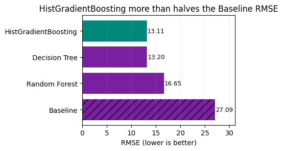

```python
rmse_values = {
    "Baseline": rmse_baseline,
    "Decision Tree": rmse_dt,
    "Random Forest": rmse_rf,
    "HistGradientBoosting": rmse_hgb
}

# Sort ascending
items = sorted(rmse_values.items(), key=lambda x: x[1])
labels = [m for m,_ in items]
scores = [s for _,s in items]

plt.figure(figsize=(5,3.2))
bars = plt.barh(labels, scores, color="#7b1fa2")

# Highlight best at the top and visually distinguish the baseline
best_index = 0
baseline_index = labels.index("Baseline")
bars[best_index].set_color("#00897b")
bars[baseline_index].set_hatch("//")

for b, s in zip(bars, scores):
    plt.text(s + 0.1, b.get_y() + b.get_height()/2, f"{s:.2f}", va='center', fontsize=9)

plt.xlabel("RMSE (lower is better)")
plt.title("HistGradientBoosting more than halves the Baseline RMSE")
plt.xlim(0, max(scores)*1.15)
plt.gca().invert_yaxis()
plt.grid(axis='x', alpha=0.2)
plt.tight_layout()
plt.show()
```

## Evaluating the Performance of the HGB Model

```python
# Evaluate model
r2 = r2_score(y_val, val_preds_hgb)
print(f"Validation R²: {r2*100:.1f}%")

# Calculate RMSE improvement
improve_pct = (rmse_baseline - rmse_hgb) / rmse_baseline * 100
print(f"RMSE improvement vs baseline: {improve_pct:.1f}%")
```

```
Validation R²: 76.6%
RMSE improvement vs baseline: 51.6%
```

## Training the Full Train Dataset Using HistGradientBoosting

```python
# Prepare full feature matrix and target
X = podcast_train.drop(columns=[target_col])
y = podcast_train[target_col]

# Identify categorical columns and one-hot encode
cat_cols_full = X.select_dtypes(include=['object', 'category']).columns.tolist()
X_enc = pd.get_dummies(X, columns=cat_cols_full, drop_first=True)

# Best HGB params: learning_rate=0.1, max_depth=6, max_iter=160, min_samples_leaf=20
print(f"Training final HistGradientBoosting on full data: "
      f"learning_rate={0.1}, max_depth={6}, max_iter={160}")

hgb_train = HistGradientBoostingRegressor(
    learning_rate=0.1,
    max_depth=6,
    max_iter=160,
    min_samples_leaf=20,
    l2_regularization=0.0,
    early_stopping=False,
    random_state=51
).fit(X_enc, y)

# Compare full train dataset to validation RMSE
train_preds = hgb_train.predict(X_enc)
train_rmse = root_mean_squared_error(y, train_preds)
print("Training on Full Train Dataset Complete:")
print(f"Full Train Dataset RMSE: {train_rmse:.2f}")
```

```
Training final HistGradientBoosting on full data: learning_rate=0.1, max_depth=6, max_iter=160
Training on Full Train Dataset Complete:
Full Train Dataset RMSE: 13.03
```

## Fitting the Model on the Test Dataset

```python
# Build encoded test feature matrix
test_features = podcast_test[X.columns]
test_enc = pd.get_dummies(test_features, columns=cat_cols_full, drop_first=True)

# Align columns (add any missing, drop extras)
test_enc = test_enc.reindex(columns=X_enc.columns, fill_value=0)

# Predict Listening Time
test_preds = hgb_train.predict(test_enc)

# Create submission DataFrame
submission = pd.DataFrame({
    'id': test_ids,
    'Listening_Time_minutes': test_preds
}).round(2)

# Output Submission to a CSV file
submission.to_csv("submission.csv", index=False)
print(f"Submission file written: submission.csv")

# Output Submission DataFrame Head
print("\nSubmission DataFrame Preview:")
submission.head()
```

```
Submission file written: submission.csv

Submission DataFrame Preview:
```

|  | id | Listening_Time_minutes |
| --- | --- | --- |
| 0 | 750000 | 56.10 |
| 1 | 750001 | 18.00 |
| 2 | 750002 | 49.26 |
| 3 | 750003 | 79.93 |
| 4 | 750004 | 48.86 |